# STAT 312R - HW1

Vinayak Mathur

27th January 2022

## Problem 1:

An article in a women’s magazine reported that women who nurse their babies feel warmer and more receptive towards their infants than mothers who bottle-feed. This conclusion was based on the following scores from a questionnaire designed to measure warmth and receptivity, given to a random sample of 10 women from each group taken from recent hospital birth records (higher score represents more warmth and reception).  
Nurse: 48.4, 51.5, 45.0, 47.0, 46.9, 47.7, 49.9, 48.5, 45.6, 48.9  
Bottle feed: 42.5, 43.8, 44.5, 47.5, 44.5, 45.6, 43.4, 44.6, 47.1, 45.8  
a) Is this an observational study or a controlled experiment? Justify your answer. (2 pt)  
b) Using SOCS, summarize the data for the two groups. (4 pts)  
c) Using your descriptions in part b), compare the scores in the two groups. (2 pts)  
d) If you or your partner were thinking about breast-feeding, what effect would this study have on your decision? Why? (2 pts)

```r
nurse <- c(48.4, 51.5, 45.0, 47.0, 46.9, 47.7, 49.9, 48.5, 45.6, 48.9)
bottle <- c(42.5, 43.8, 44.5, 47.5, 44.5, 45.6, 43.4, 44.6, 47.1, 45.8)
summary(nurse)
```

```
##    Min. 1st Qu.  Median    Mean 3rd Qu.    Max.
##   45.00   46.92   48.05   47.94   48.80   51.50
```

```r
summary(bottle)
```

```
##    Min. 1st Qu.  Median    Mean 3rd Qu.    Max.
##   42.50   43.98   44.55   44.93   45.75   47.50
```

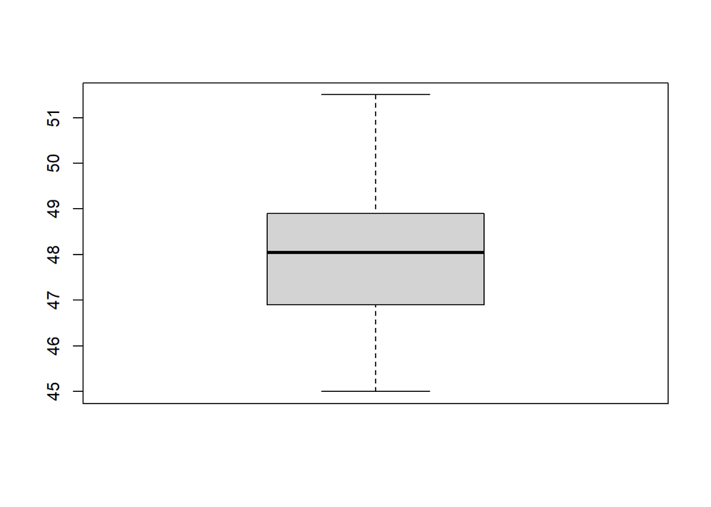

```r
boxplot(nurse)
```

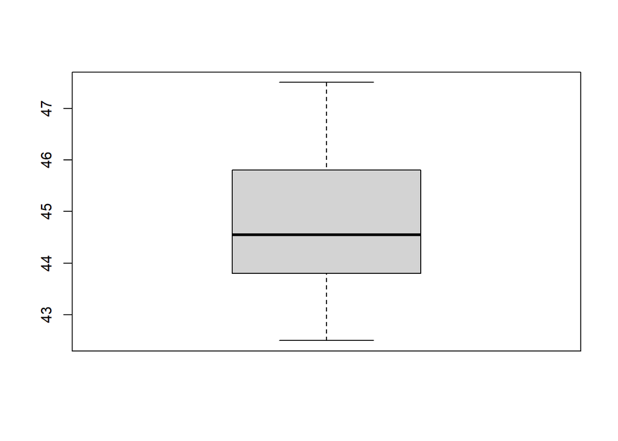

```r
boxplot(bottle)
```

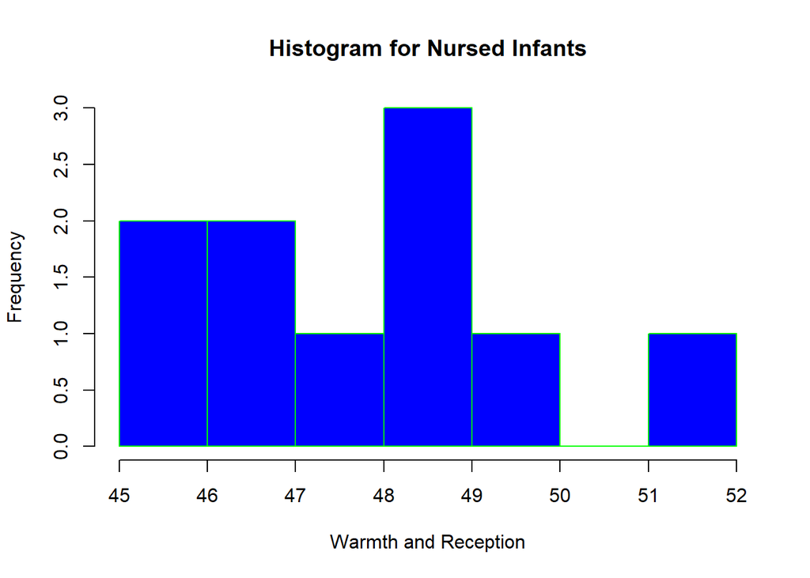

```r
hist(nurse,
     main="Histogram for Nursed Infants",
     xlab="Warmth and Reception",
     border="green",
     col="blue")
```

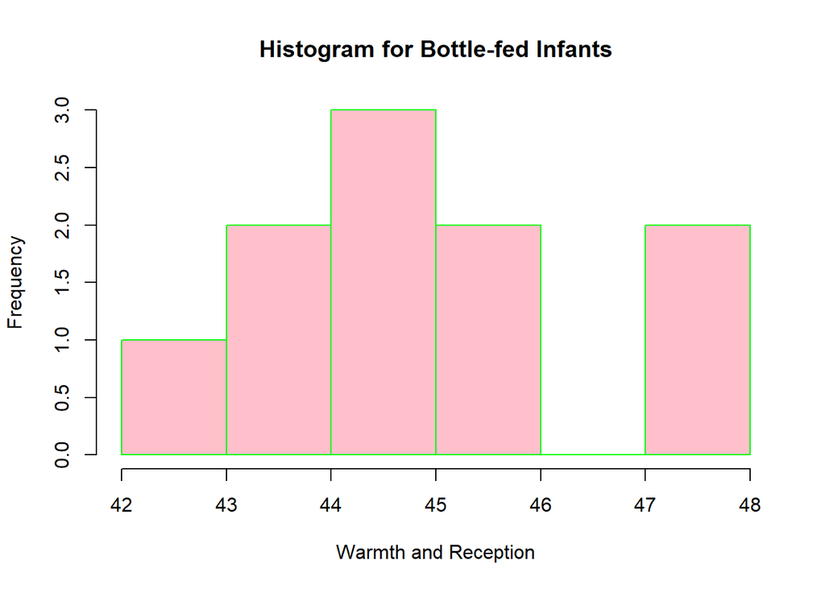

```r
hist(bottle,
     main="Histogram for Bottle-fed Infants",
     xlab="Warmth and Reception",
     border="green",
     col="pink")
```

## Problem 2:

One of the authors (DCM) has a Mercedes-Benz 500 SL Roadster. It is a 2003 model and has fairly low mileage (currently 60,112 miles on the odometer). He is interested in learning how his car’s mileage compares with the mileage on similar SLs. The table below contains the mileage on 100 Mercedes-Benz SLs from the model years 2003–2009 taken from the Cars.com website.  
### a)  
Calculate the sample mean and standard deviation of the odometer readings.  
### b)  
Construct a histogram of the odometer readings and comment on the shape of the data distribution.  
### c)  
Construct a stem-and-leaf diagram of the odometer readings.  
### d)  
What is the percentile of DCM’s mileage?

```r
miles <- read.table("MercMileage.txt")$V1
dcm <- 60112
mean(miles)
```

```
## [1] 34232.05
```

```r
sd(miles)
```

```
## [1] 20414.52
```

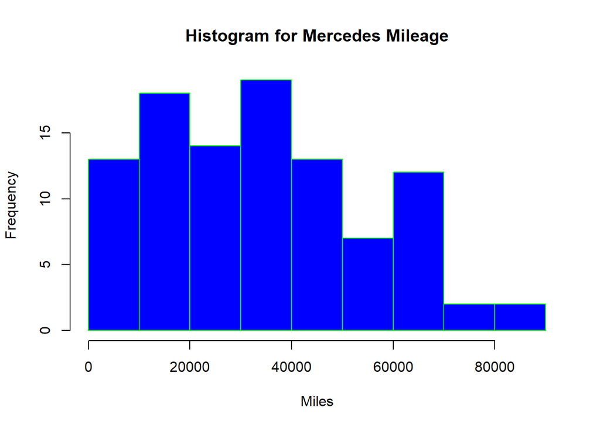

```r
hist(miles,
     main="Histogram for Mercedes Mileage",
     xlab="Miles",
     border="green",
     col="blue")
```

```r
stem(miles, scale = 2)
```

```
##
##   The decimal point is 4 digit(s) to the right of the |
##
##   0 | 222444
##   0 | 5668999
##   1 | 024
##   1 | 5566667888899
##   2 | 001223
##   2 | 6667999999
##   3 | 0001222333444
##   3 | 678888
##   4 | 011333
##   4 | 5678999
##   5 | 1124
##   5 | 689
##   6 | 00133334
##   6 | 5677
##   7 | 2
##   7 | 8
##   8 | 4
##   8 | 5
```

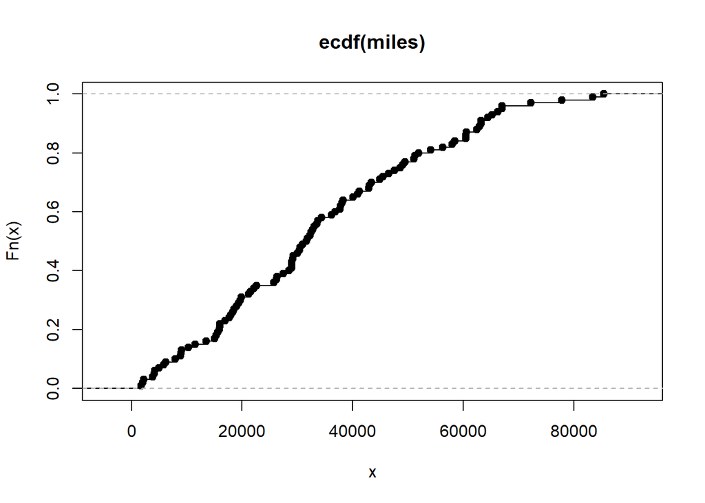

```r
plot(ecdf(miles))
```

```r
ecdf(miles)(dcm)
```

```
## [1] 0.84
```

ans) From the above calculations:  
a) mean = 34232.05 miles  
standard deviation = 20414.52  
d) 84%